# Electricity Generation Estimation

We will base our analysis on the monthly data (index) provided by the Federal Reserve in https://fred.stlouisfed.org/series/IPG2211N

```r
library(fpp)
library(dplyr)
```

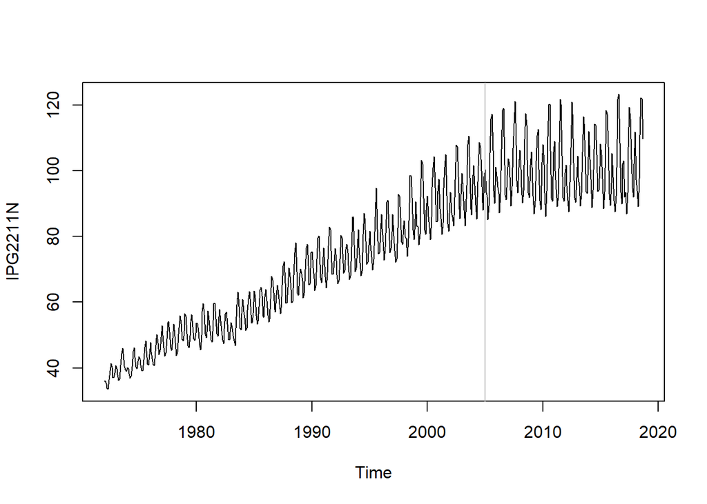

```r
PG <- read.csv("IPG2211N.csv") %>%
  select(-DATE) %>%
  ts(start=c(1972,1), frequency=12)
plot(PG)
abline(v=c(2005,1), col="gray")
```

Initially we will set up as training data the series from January 1972 through December 1995, and the testing set as the data from January 1996 through December 2000. First we will analyze the data during the growth period. To maintain consistency across the class, please execute the following two command to generate the training and testing data sets as indicated:

```r
PG1.tr <- window(PG, end=c(1995,12))
PG1.te <- window(PG, start=c(1996,1), end=c(2000,12))
```

####1. Preliminary analysis of training data: ###### Obtain the Box-Cox transformation parameter lambda for the training set PG1.tr

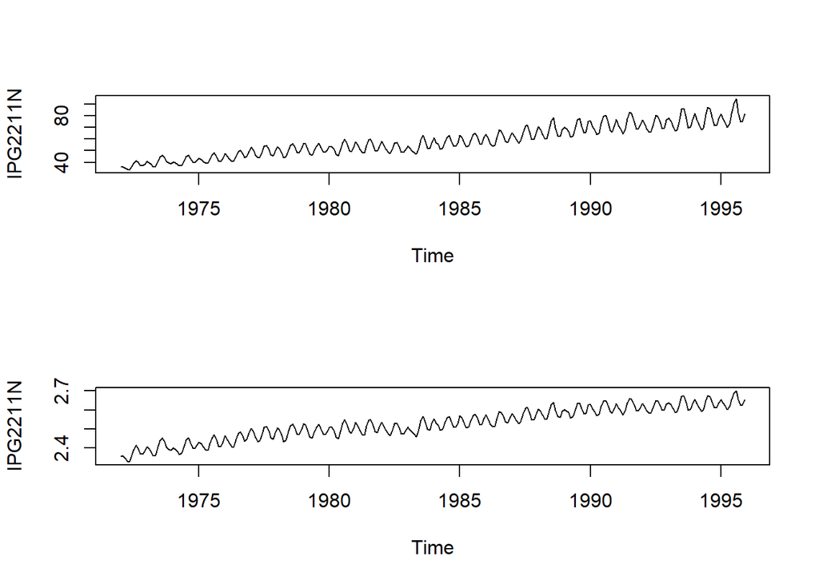

```r
L <- BoxCox.lambda(PG1.tr)
z <- BoxCox(PG1.tr,L)
par(mfrow=c(2,1))
plot(PG1.tr)
plot(z)
```

```r
par(mfrow=c(1,1))

print("following is the best value of Lambda")
```

```
## [1] "following is the best value of Lambda"
```

```r
print(L)
```

```
## [1] -0.2530983
```

###### Use the **ggtsdisplay(…, lag=48)** function to examine *ACF* and *PACF* of the Box-Cox transformed series with a non-seasonal difference. Do the differenced and transformed series look stationary?

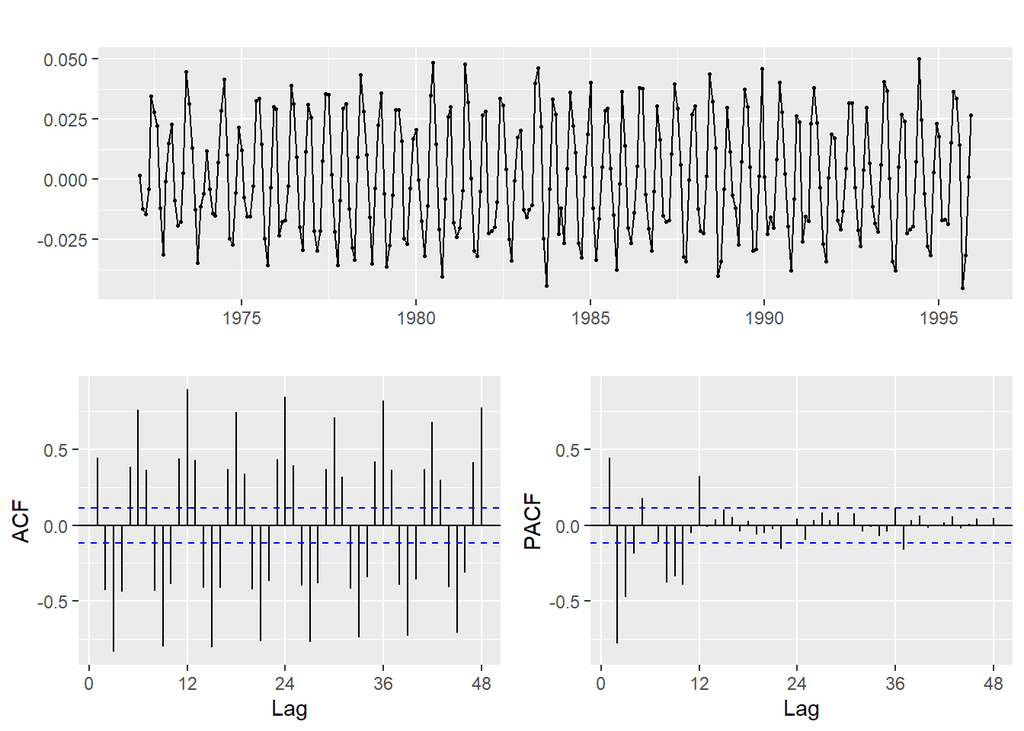

```r
#ggtsdisplay(z,lag = 48)
z %>% diff(1) %>% ggtsdisplay(lag=48)
```

```r
adf.test(z%>% diff(1), alternative = 'stationary', k =12)
```

```
##
##  Augmented Dickey-Fuller Test
##
## data:  z %>% diff(1)
## Dickey-Fuller = -5.2335, Lag order = 12, p-value = 0.01
## alternative hypothesis: stationary
```

Yes, the series looks stationary as there are variations around the mean (similar to white noise). However, ACF is not dying down quickly, which is expected of stationary series. ACF showcases a pattern and hence there seems to be seasonality present in the series. Hence, seasonal difference is required with p= 9 ;=>0 q= 9;=>0 P = 1; 3rd is barely significant Q = 4 =>0

###### Use the **ggtsdisplay(…, lag=48)** function to examine *ACF* and *PACF* of the Box-Cox transformed series with a seasonal difference. Do the differenced and transformed series look stationary?

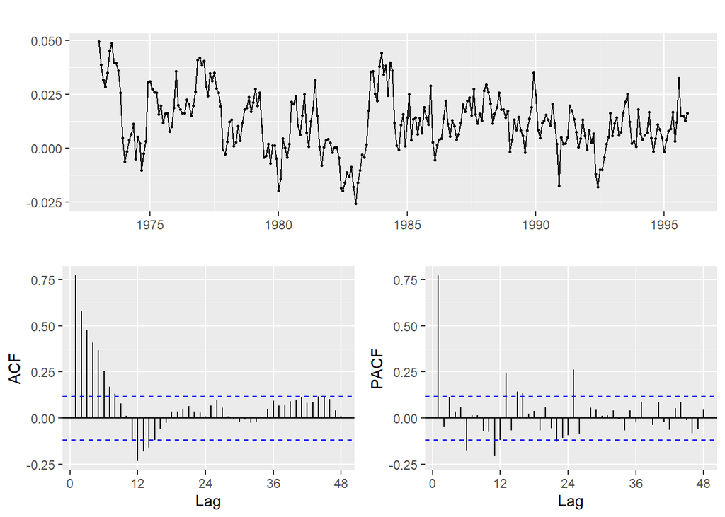

```r
z %>% diff(lag = 12) %>% ggtsdisplay(lag=48)
```

```r
adf.test(z%>% diff(lag=12), alternative = 'stationary', k =12)
```

```
##
##  Augmented Dickey-Fuller Test
##
## data:  z %>% diff(lag = 12)
## Dickey-Fuller = -4.3727, Lag order = 12, p-value = 0.01
## alternative hypothesis: stationary
```

Now, since the seasonal difference is taken, the series seems to be stationary. ACF dies down gradually. p=6; q=8; P=2; Q=2

###### Use the **ggtsdisplay(…, lag=48)** function to examine *ACF* and *PACF* of the Box-Cox transformed series with both a seasonal difference and a non-seasonal difference. Do the differenced and transformed series look stationary?

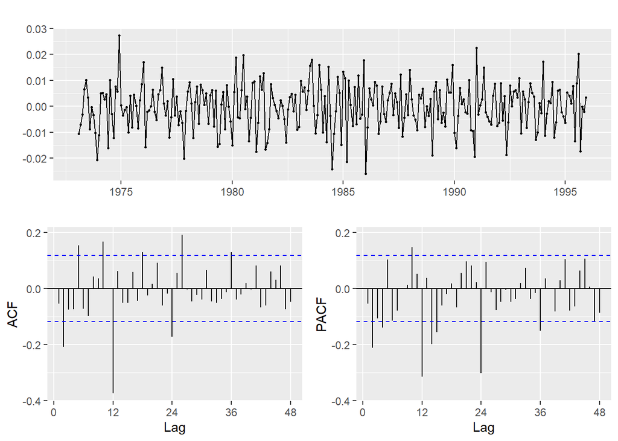

```r
z %>% diff() %>% diff(lag = 12) %>%  ggtsdisplay(lag=48)
```

Seems like the series is stationary;

p=9; q=5; P=3; Q=3

###### Run the **adf.test(…)** on the above series. What do you conclude from the test?

```r
z_tran <- z %>% diff(1) %>% diff(lag = 12)
adf.test(z_tran, alternative = 'stationary', k =12)
```

```
##
##  Augmented Dickey-Fuller Test
##
## data:  z_tran
## Dickey-Fuller = -5.9947, Lag order = 12, p-value = 0.01
## alternative hypothesis: stationary
```

- Answer:

p-value is smaller than 0.05. Hence, null hypothesis of unit root is rejected. The series is stationary

###### If you were to fit an *ARIMA* model to each of the (three) differenced series you obtained above, what would be the maximum order of the $(p,d,q) (P,D,Q)_{12}$ model in each case? (i.e., what is the maximum values of $p,P,q$ and $Q$ for each of the value combinations of $d$ and $D$?)

- Answer:
- Case 1 :

Non-seasonal difference : p= 9 ; q= 9; P = 3; Q = 4; d=1; D=0

- Case 2:

Seasonal Difference:

d=0; D=1; p=6; q=8; P=2; Q=2

- Case 3: Seasonal + non-seasonal difference :

d=1; D=1; p=9; q=5; P=3; Q=3

####2. Automatic ARIMA model selection:

###### Run the **auto.arima(…)** function to fit an ARIMA model on the Box-Cox transformation of the PG1.tr dataset, and report the order of the model, the value of the model parameters and the value of the AICc and BIC information criteria.

```r
arima_q2 <- auto.arima(PG1.tr, lambda = L)
print("Model Parameters: ")
```

```
## [1] "Model Parameters: "
```

```r
summary(arima_q2)
```

```
## Series: PG1.tr
## ARIMA(2,1,1)(0,1,1)[12]
## Box Cox transformation: lambda= -0.2530983
##
## Coefficients:
##          ar1      ar2      ma1     sma1
##       0.6187  -0.2491  -0.6813  -0.8008
## s.e.  0.1150   0.0655   0.1096   0.0477
##
## sigma^2 estimated as 4.918e-05:  log likelihood=970.21
## AIC=-1930.42   AICc=-1930.19   BIC=-1912.33
##
## Training set error measures:
##                      ME     RMSE       MAE        MPE     MAPE     MASE
## Training set -0.0935554 1.176245 0.8729458 -0.1941531 1.476424 0.385567
##                    ACF1
## Training set -0.1173698
```

###### Use the **checkresiduals(…)** function to assess the validity of the model you obtained in (1). Based on the results you obtained comment on the validity of the model.

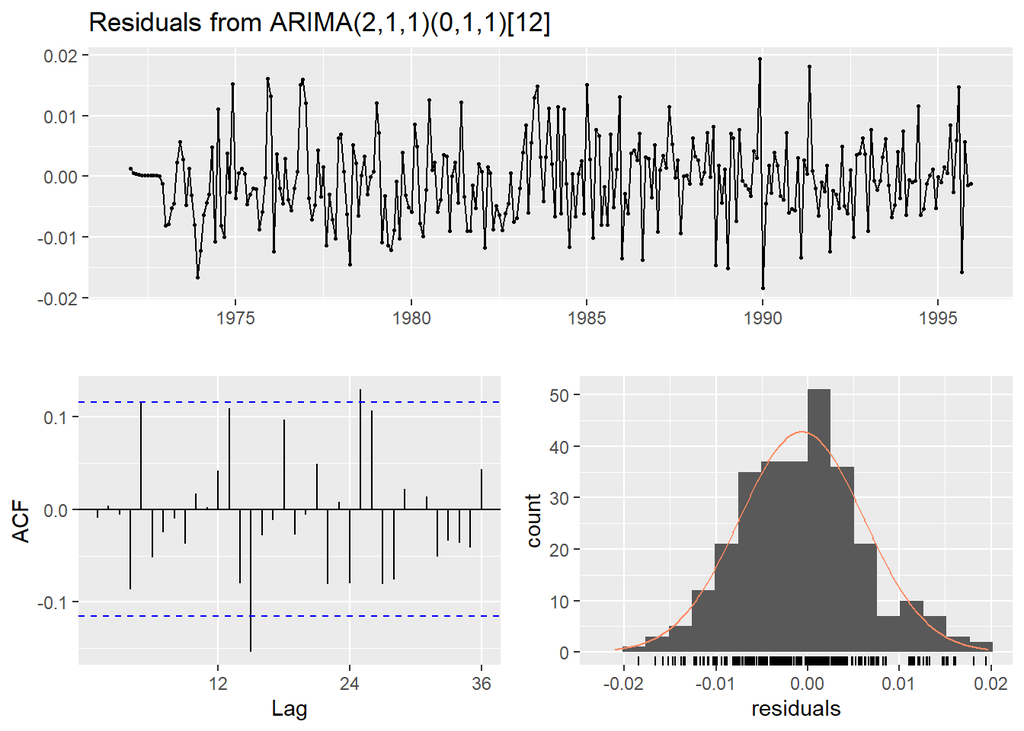

```
##
##  Ljung-Box test
##
## data:  Residuals from ARIMA(2,1,1)(0,1,1)[12]
## Q* = 29.262, df = 20, p-value = 0.08272
##
## Model df: 4.   Total lags used: 24
```

```r
checkresiduals(arima_q2)
```

###### Use the **forecast(…)** function to prepare a 60 month-ahead (5-year) forecast for the electricity generation and then overlay the actual data for electricity generation.

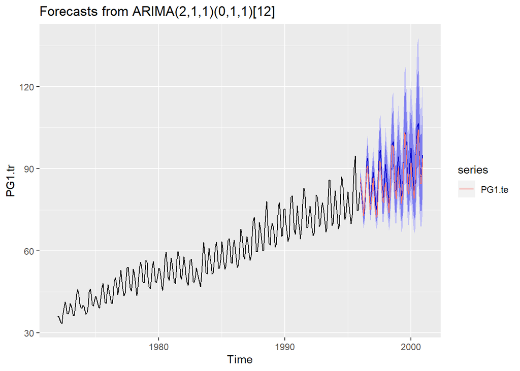

```r
forecast_q3 <- forecast(arima_q2,h = 60)
autoplot(forecast_q3)+
autolayer(PG1.te)
```

###### Use the **accuracy(…)** function to obtain the training and testing fit (PG1.te) metrics for the model obtained. Based on the visual inspection of the forecast plot and the out-of-sample fit statistics comment on the forecast bias.

```r
accuracy(forecast_q3,PG1.te)
```

```
##                      ME     RMSE       MAE        MPE     MAPE     MASE
## Training set -0.0935554 1.176245 0.8729458 -0.1941531 1.476424 0.385567
## Test set     -2.2196194 3.047559 2.5506190 -2.6392460 3.028170 1.126570
##                    ACF1 Theil's U
## Training set -0.1173698        NA
## Test set      0.5894791 0.4885983
```

- Training error is lower than test error, indicating higher bias in the model.
- Confidence interval also seems to be expanding.

####3. Manual Model Selection on $(p,0,q) (P,1,Q)_{12}$:

- Search manually for a model on the seasonally differenced series to improve on the automatic selection in (2). To limit your manual search do not exceed the maximum values of $p,q,P$ and $Q$ that you identified in (1).

```r
## Manual Search with max 4 as the values for p,q,P and Q :


pval <- c(0:4)
qval <- c(0:4)
Qval <- c(0:4)
Pval <- c(0:4)
q3_df <- data.frame()
counter <- 0
aicflag <- 0

for(i in 1:4){
  #print(pval[i])
  for(j in 1:4 ){

    for(k in 1:4){
      for(l in 1:4){
      counter = counter+1
      #print(counter)
      tryCatch({

      p <- pval[i]
      q <- qval[j]
      Q <- Qval[k]
      P <- Pval[l]
      train <- PG1.tr %>% Arima(order= c(p,0,q), seasonal= c(P,1,Q), lambda = L)
      trainAic <- train$aic

      #print(trainAic)
      aicflag <- trainAic
      trainAICc <- train$aicc
      trainBIC <- train$bic
      forecast_train <- forecast(train,h=60)

      forecast_train_summ <- accuracy(forecast_train,PG1.te)

      train_mape <- forecast_train_summ[2,5]
      train_mase <- forecast_train_summ[2,6]
      #print(train_mape)

      q3_df <- rbind(q3_df,c(trainAic,trainAICc,trainBIC,train_mape,train_mase,p[1],0,q[1],P[1],1,Q[1]))


      }, error = function(e){ })
                next


      }


    }

  }

}

colnames(q3_df) <- c("AIC","AICc","BIC","MAPE","MASE","pvalue","dvalue","qvalue","Pvalue","Dvalue","Qvalue")

print("Model parameters p,q,P,Q \n")
```

```
## [1] "Model parameters p,q,P,Q \n"
```

```r
print(q3_df)
```

```
##           AIC      AICc       BIC     MAPE      MASE pvalue dvalue qvalue
## 1   -1421.683 -1421.668 -1418.062 6.772913 2.6116937      0      0      0
## 2   -1440.888 -1440.844 -1433.647 5.907771 2.2760798      0      0      0
## 3   -1479.989 -1479.901 -1469.128 3.951520 1.5243662      0      0      0
## 4   -1515.099 -1514.952 -1500.618 2.866771 1.1160021      0      0      0
## 5   -1431.786 -1431.742 -1424.545 6.428673 2.4786186      0      0      0
## 6   -1529.728 -1529.640 -1518.867 4.008520 1.5387322      0      0      0
## 7   -1541.247 -1541.100 -1526.766 3.053401 1.1661801      0      0      0
## 8   -1539.484 -1539.262 -1521.382 2.856211 1.0901595      0      0      0
## 9   -1450.457 -1450.369 -1439.596 5.728566 2.2093153      0      0      0
## 10  -1540.333 -1540.185 -1525.851 2.854156 1.0889382      0      0      0
## 11  -1539.352 -1539.130 -1521.250 2.970618 1.1341869      0      0      0
## 12  -1537.980 -1537.668 -1516.258 2.847498 1.0879133      0      0      0
## 13  -1488.258 -1488.111 -1473.777 3.819432 1.4722963      0      0      0
## 14  -1541.040 -1540.818 -1522.938 3.252555 1.2453364      0      0      0
```

[output cut: 475 more lines]

Checking for some models based on the table above

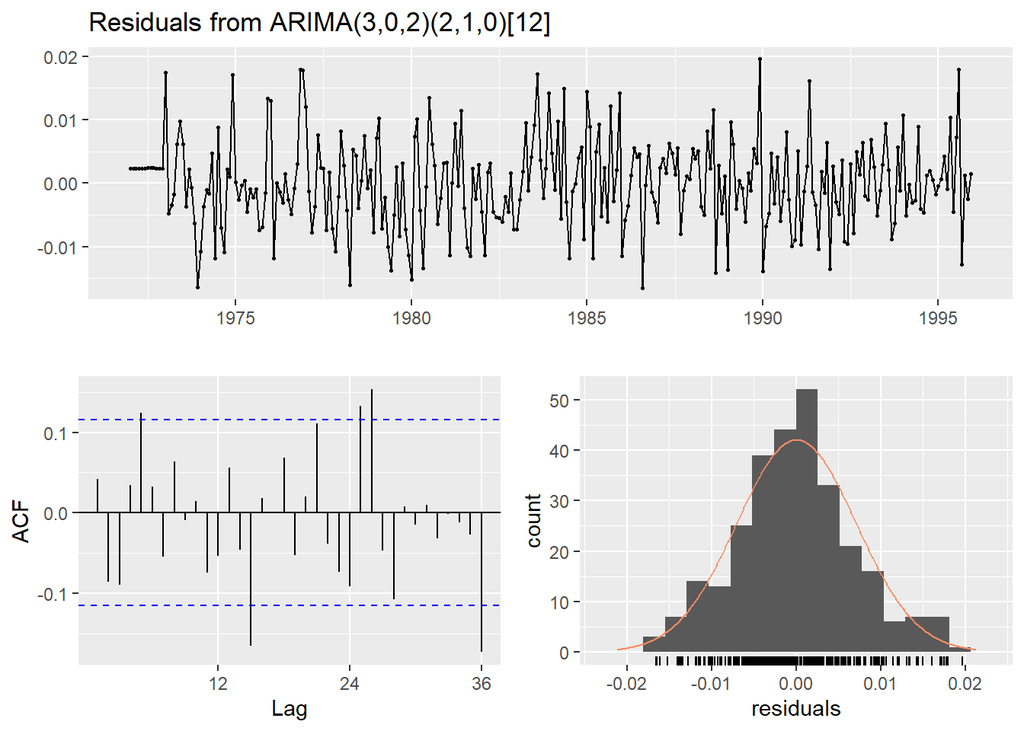

```
##
##  Ljung-Box test
##
## data:  Residuals from ARIMA(3,0,2)(2,1,0)[12]
## Q* = 36.108, df = 17, p-value = 0.004437
##
## Model df: 7.   Total lags used: 24
##
##
##  Ljung-Box test
##
## data:  Residuals from ARIMA(3,0,2)(2,1,0)[12]
## Q* = 36.108, df = 17, p-value = 0.004437
```

```r
test_q3<- PG1.tr %>%
       Arima(order=c(3,0,2), seasonal=c(2,1,0), lambda = L)

print(checkresiduals(test_q3))
```

```r
forecast_q3 <- forecast(test_q3, h= 60)
print(accuracy(forecast_q3,PG1.te))
```

```
##                        ME     RMSE      MAE         MPE     MAPE      MASE
## Training set  0.004105008 1.215662 0.915708 -0.01090427 1.543931 0.4044544
## Test set     -0.804777851 2.172735 1.801379 -0.97011195 2.115546 0.7956419
##                     ACF1 Theil's U
## Training set -0.05228353        NA
## Test set      0.47866951 0.3487089
```

###### Report on the best model that you identified in each case and comment on its *AIC*, *AICc* and *BIC*. How do your model compares with the one found by **auto.arima(…)**?

####4. Manual Model Selection on $(p,1,q) (P,0,Q)_{12}$:

- Search manually for a model on the once-differenced series to improve on the automatic selection in (2). To limit your manual search do not exceed the maximum values of $p,q,P$ and $Q$ that you identified in (1).

```r
## Manual search for model parameters p,q,P,Q :

pval <- c(0,1,2)
qval <- c(0,1)
Qval <- c(0,1)
q4_df <- data.frame()

for(i in 1:3){
  #print(pval[i])
  for(j in 1:2 ){

    for(k in 1:2){
      p <- pval[i]
      q <- qval[j]
      Q <- Qval[k]
      train <- PG1.tr %>% Arima(order= c(p,1,q), seasonal= c(0,0,Q), lambda = L)
      trainAic <- train$aic

      trainAICc <- train$aicc
      trainBIC <- train$bic
      forecast_train <- forecast(train,h=60)

      forecast_train_summ <- accuracy(forecast_train,PG1.te)

      train_mape <- forecast_train_summ[2,5]
      train_mase <- forecast_train_summ[2,6]

      q4_df <- rbind(q4_df,c(trainAic,trainAICc,trainBIC,train_mape,train_mase,p[1],1,q[1],0,0,Q[1]))

    }

  }
}

colnames(q4_df) <- c("AIC","AICc","BIC","MAPE","MASE","pvalue","dvalue","qvalue","Pvalue","Dvalue","Qvalue")


print("Following are the various values for differenet parameters of p,q,P,Q \n")
```

```
## [1] "Following are the various values for differenet parameters of p,q,P,Q \n"
```

```r
print(q4_df)
```

```
##          AIC      AICc       BIC     MAPE     MASE pvalue dvalue qvalue Pvalue
## 1  -1321.596 -1321.582 -1317.936 7.482072 2.963566      0      1      0      0
## 2  -1556.465 -1556.423 -1549.146 6.952291 2.641070      0      1      0      0
## 3  -1473.143 -1473.101 -1465.824 7.730425 2.899575      0      1      1      0
## 4  -1628.905 -1628.820 -1617.926 7.842772 2.905629      0      1      1      0
## 5  -1383.538 -1383.496 -1376.219 7.945900 2.965630      1      1      0      0
## 6  -1588.310 -1588.225 -1577.332 8.214483 3.026258      1      1      0      0
## 7  -1476.686 -1476.602 -1465.708 8.541990 3.147172      1      1      1      0
## 8  -1626.907 -1626.765 -1612.269 7.854216 2.909239      1      1      1      0
## 9  -1654.589 -1654.505 -1643.611 7.074389 2.820310      2      1      0      0
## 10 -1723.525 -1723.383 -1708.887 6.485372 2.559009      2      1      0      0
## 11 -1716.488 -1716.346 -1701.850 6.725412 2.668196      2      1      1      0
## 12 -1790.371 -1790.158 -1772.074 6.288858 2.457643      2      1      1      0
##    Dvalue Qvalue
## 1       0      0
## 2       0      1
## 3       0      0
## 4       0      1
## 5       0      0
## 6       0      1
## 7       0      0
## 8       0      1
## 9       0      0
## 10      0      1
## 11      0      0
## 12      0      1
```

###### Report on the best model that you identified in each case and comment on its *AIC*, *AICc* and *BIC*. How do your model compares with the ones found in (2) and (3)?

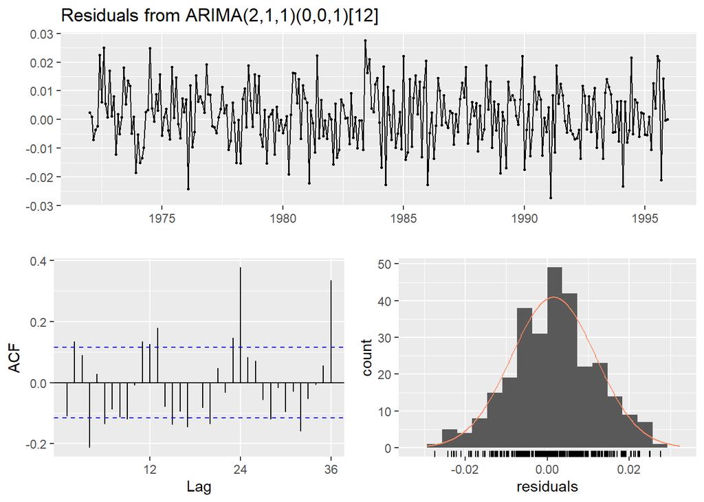

```
##
##  Ljung-Box test
##
## data:  Residuals from ARIMA(2,1,1)(0,0,1)[12]
## Q* = 138.74, df = 20, p-value < 2.2e-16
##
## Model df: 4.   Total lags used: 24
##
##
##  Ljung-Box test
##
## data:  Residuals from ARIMA(2,1,1)(0,0,1)[12]
## Q* = 138.74, df = 20, p-value < 2.2e-16
```

```r
test_q5<- PG1.tr %>%
       Arima(order=c(2,1,1), seasonal=c(0,0,1), lambda = L)

print(checkresiduals(test_q5))
```

```r
forecast_test_q5 <- forecast(test_q5, h= 60)
print(accuracy(forecast_test_q5,PG1.te))
```

```
##                     ME     RMSE      MAE       MPE     MAPE      MASE
## Training set 0.2540266 1.795301 1.366335 0.3788942 2.294645 0.6034896
## Test set     1.6718851 7.501346 5.564246 1.2444906 6.288858 2.4576431
##                    ACF1 Theil's U
## Training set -0.1354920        NA
## Test set      0.6854491  1.126266
```

- Answer:

Manual model with difference : ARIMA(2,1,1)(0,0,1)[12]

####5. ARIMA model for the expanded training set:

###### No we redefine the training and testing sets as follows:

```r
PG2.tr <- window(PG, end=c(2011,12))
```

###### Obtain the Box-Cox transformation parameter lambda for the training set **PG2.tr**

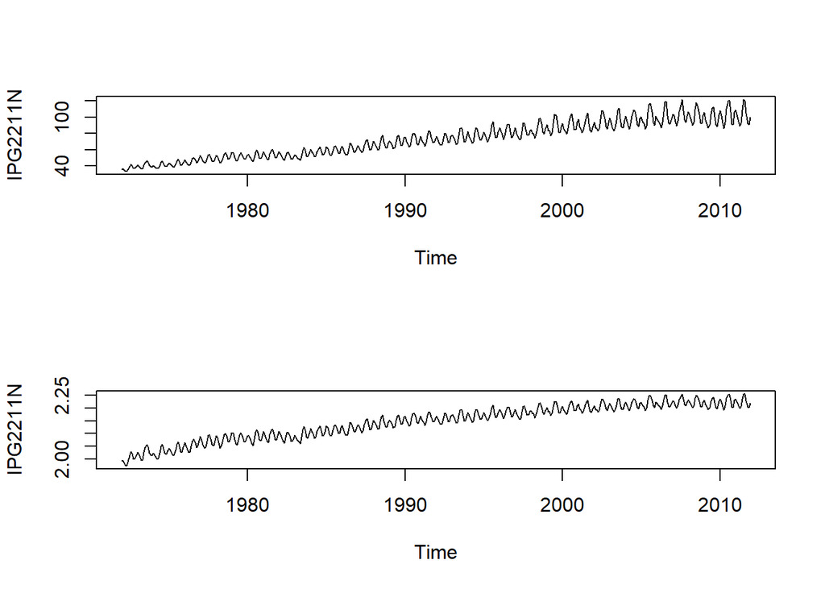

```r
L <- BoxCox.lambda(PG2.tr)
z <- BoxCox(PG2.tr,L)
par(mfrow=c(2,1))
plot(PG2.tr)
plot(z)
```

```r
par(mfrow=c(1,1))

print("following is the best value of Lambda")
```

```
## [1] "following is the best value of Lambda"
```

```r
print(L)
```

```
## [1] -0.367202
```

###### Difference the transformed series once at the seasonal and non-seasonal levels (i.e.,$d=1$ and $D=1$) and run the **adf.test(…)** on the resulting series. What do you conclude from the test?

```r
q5_z <- z %>% diff(1) %>% diff(lag = 12)
adf.test(q5_z, alternative = 'stationary', k =12)
```

```
##
##  Augmented Dickey-Fuller Test
##
## data:  q5_z
## Dickey-Fuller = -8.0736, Lag order = 12, p-value = 0.01
## alternative hypothesis: stationary
```

###### If you were to fit an ARIMA model to the time series you obtained above, what would be the maximum order of the $(p,1,q) (P,1,Q)_{12}$ model? (i.e., what is the maximum values of $p,P,q$ and $Q$? )

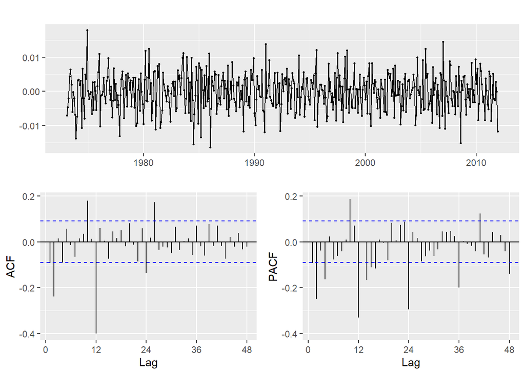

```r
z %>% diff(1) %>% diff(lag = 12) %>% ggtsdisplay(lag=48)
```

From ACF & PACF, following parameters are estimated :

P= 4 Q=2 p=4 q=2

####6. Automatic ARIMA model selection on the expanded dataset:

###### Run the **auto.arima(…)** function to fit an *ARIMA* model on the Box-Cox transformation of the **PG2.tr** dataset, and report the order of the model, the value of the model parameters and the value of the *AIC*, *AICc* and *BIC*?

```r
arima_q6 <- auto.arima(PG2.tr, lambda = L)
print("Model Parameters : ")
```

```
## [1] "Model Parameters : "
```

```r
summary(arima_q6)
```

```
## Series: PG2.tr
## ARIMA(1,1,3)(0,1,1)[12]
## Box Cox transformation: lambda= -0.367202
##
## Coefficients:
##          ar1      ma1      ma2     ma3     sma1
##       0.4588  -0.5969  -0.2423  0.0614  -0.7836
## s.e.  0.3294   0.3317   0.0741  0.1345   0.0318
##
## sigma^2 estimated as 1.798e-05:  log likelihood=1886.56
## AIC=-3761.13   AICc=-3760.95   BIC=-3736.25
##
## Training set error measures:
##                      ME     RMSE      MAE        MPE     MAPE      MASE
## Training set -0.1266131 1.567936 1.147096 -0.2094499 1.544572 0.4612656
##                    ACF1
## Training set -0.1131731
```

###### Execute the residual diagnostics and comment on the validity of the model.

```r
print("Residuals :")
```

```
## [1] "Residuals :"
```

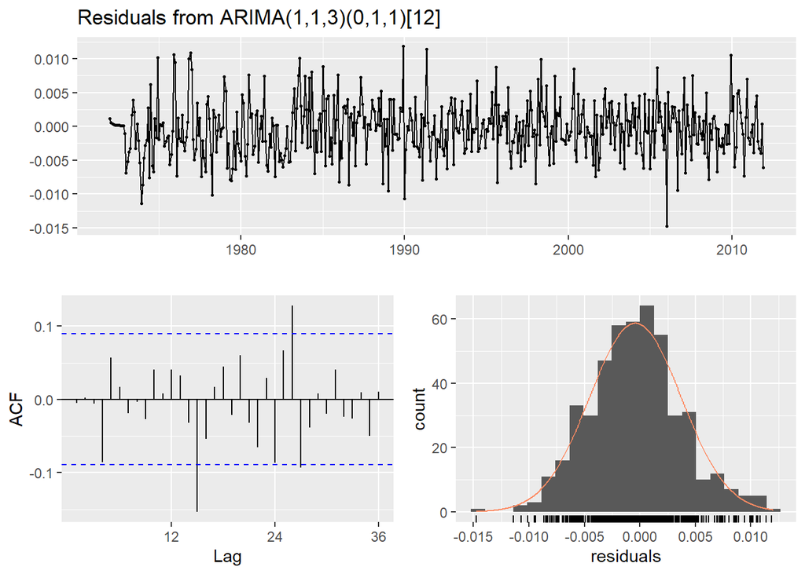

```
##
##  Ljung-Box test
##
## data:  Residuals from ARIMA(1,1,3)(0,1,1)[12]
## Q* = 31.946, df = 19, p-value = 0.03169
##
## Model df: 5.   Total lags used: 24
##
##
##  Ljung-Box test
##
## data:  Residuals from ARIMA(1,1,3)(0,1,1)[12]
## Q* = 31.946, df = 19, p-value = 0.03169
```

```r
print(checkresiduals(arima_q6))
```

####7. Automatic ARIMA model selection with a reduced training dataset:

###### As the patterns of consumption and generation changed substantially on 2005, before setting on a forecasting model we will try reducing the training set to information posterior to 2005. To this end we define the training data set as follows:

```r
PG3.tr <- window(PG, start=c(2005,1), end=c(2011,12))
PG3.te <- window(PG, start=c(2012,1), end=c(2017,12))
```

###### Now run the **auto.arima(…)** function to fit a model on the **PG3.tr** dataset, and report the order of the model, the value of the model parameters, and the values of *AIC*, *AICc* and *BIC*.

```r
arima_q7 <- auto.arima(PG3.tr)
print("Model Parameters: ")
```

```
## [1] "Model Parameters: "
```

```r
summary(arima_q7)
```

```
## Series: PG3.tr
## ARIMA(0,0,1)(2,1,1)[12]
##
## Coefficients:
##          ma1     sar1     sar2     sma1
##       0.6702  -0.0635  -0.2438  -0.6571
## s.e.  0.0868   0.3035   0.1998   0.3845
##
## sigma^2 estimated as 5.392:  log likelihood=-166.8
## AIC=343.61   AICc=344.52   BIC=354.99
##
## Training set error measures:
##                     ME     RMSE      MAE      MPE     MAPE      MASE       ACF1
## Training set 0.3704143 2.089163 1.584466 0.339566 1.554297 0.5672604 0.06623551
```

###### Diagnose the model’s residuals to assess the validity of the model you obtained above. Based on the results you obtained comment on the validity of the model.

```r
print("Residuals: ")
```

```
## [1] "Residuals: "
```

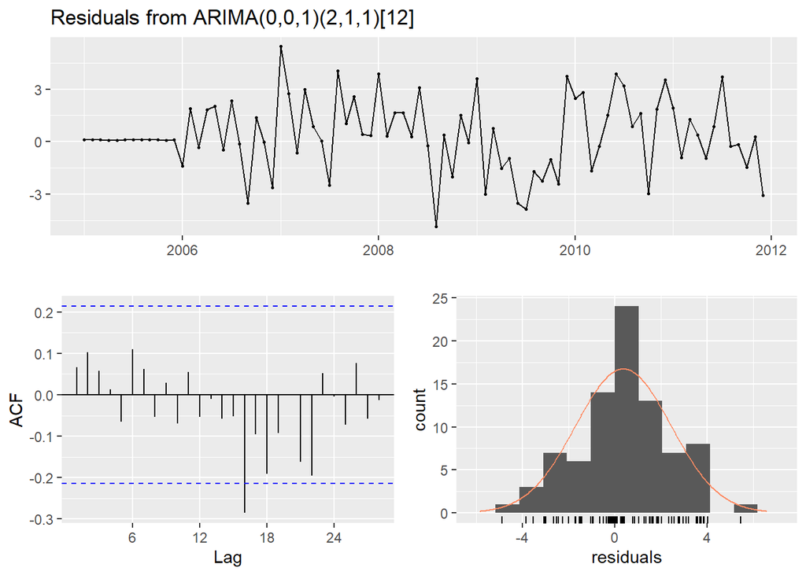

```
##
##  Ljung-Box test
##
## data:  Residuals from ARIMA(0,0,1)(2,1,1)[12]
## Q* = 15.21, df = 13, p-value = 0.2944
##
## Model df: 4.   Total lags used: 17
##
##
##  Ljung-Box test
##
## data:  Residuals from ARIMA(0,0,1)(2,1,1)[12]
## Q* = 15.21, df = 13, p-value = 0.2944
```

```r
print(checkresiduals(arima_q7))
```

###### Using the **PG3.tr** dataset, try to get a better model than the one obtained by the **auto.arima(…)** function, possibly changing also the number of differences. Use the information criteria and the validity of the model to select the best model.

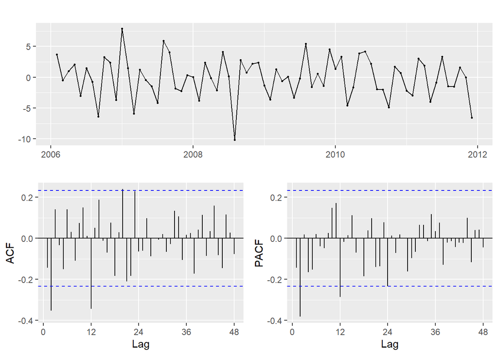

```r
PG3.tr  %>% diff(1) %>% diff(lag = 12) %>% ggtsdisplay(lag=48)
```

```r
## Manual search for model parameters:

pval <- c(0,1,2)
qval <- c(0,1,2)
Qval <- c(0,1)
Pval <- c(0,1)
dval <- c(0,1,2)
Dval <- c(0,1,2)

q7_df <- data.frame()
counter = 0
for(i in 1:3){
  #print(pval[i])
  for(j in 1:3 ){
    for(k in 1:2){
      for(l in 1:2){
          for(n in 1:3){
            for(o in 1:3){

                p <- pval[i]
                q <- qval[j]
                Q <- Qval[k]
                P <- Pval[l]
                d <- dval[n]
                D <- Dval[o]
                counter = counter +1



                  tryCatch({
                  train <-  PG3.tr %>% Arima(order= c(p,d,q), seasonal= c(P,D,Q))

                trainAic <- train$aic
                trainAICc <- train$aicc
                trainBIC <- train$bic
                forecast_train <- forecast(train,h=60)
                forecast_train_summ <- accuracy(forecast_train,PG3.te)
                train_mape <- forecast_train_summ[2,5]
                train_mase <- forecast_train_summ[2,6]

                q7_df <- rbind(q7_df,c(trainAic,trainAICc,trainBIC,train_mape,train_mase,p[1],d[1],q[1],P[1],D[1],Q[1]))
                  }, error = function(e){ })
                next

            }
          }
        }
      }
    }
  }


colnames(q7_df) <- c("AIC","AICc","BIC","MAPE","MASE","pvalue","dvalue","qvalue","Pvalue","Dvalue","Qvalue")

print("Model parameters of p,q,P,Q \n")
```

```
## [1] "Model parameters of p,q,P,Q \n"
```

```r
print(q7_df)
```

```
##          AIC     AICc      BIC        MAPE        MASE pvalue dvalue qvalue
## 1   625.1874 625.3356 630.0491    8.093495   2.9688245      0      0      0
## 2   386.7035 386.7606 388.9802    2.346188   0.8665062      0      0      0
## 3   389.8813 389.9502 391.9756    6.137041   2.2241843      0      0      0
## 4   598.3166 598.3660 600.7354    7.988190   2.9688245      0      1      0
## 5   370.1760 370.2339 372.4386   18.674239   6.7154215      0      1      0
## 6   376.2635 376.3337 378.3411   67.519906  24.3661608      0      1      0
## 7   600.0125 600.0625 602.4192  259.164216  93.1658220      0      2      0
## 8   427.2652 427.3240 429.5137  457.274942 164.9465584      0      2      0
## 9   410.7817 410.8532 412.8422 1002.438919 361.6598487      0      2      0
## 10  478.5994 478.8994 485.8918    2.397837   0.8746850      0      0      0
## 11  378.9673 379.1412 383.5206    2.299799   0.8487298      0      0      0
## 12  366.2013 366.4118 370.3900    5.989813   2.2745388      0      0      0
## 13  456.6527 456.8027 461.4904   16.217619   5.8914761      0      1      0
## 14  360.8154 360.9919 365.3408   11.177741   4.0088072      0      1      0
```

[output cut: 605 more lines]

- Model Paramters:
- AIC =420.4605
- AICc= 421.9538
- BIC = 437.3924

###### For the best model found thus far, prepare a 72 month-ahead forecast for the electricity generation and then overlay the actual data for electricity generation.

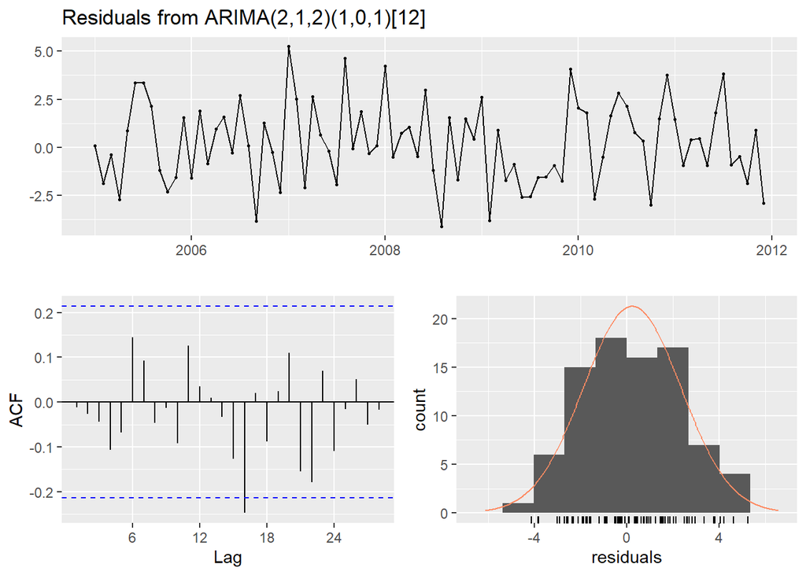

```
##
##  Ljung-Box test
##
## data:  Residuals from ARIMA(2,1,2)(1,0,1)[12]
## Q* = 15.533, df = 11, p-value = 0.1594
##
## Model df: 6.   Total lags used: 17
##
##
##  Ljung-Box test
##
## data:  Residuals from ARIMA(2,1,2)(1,0,1)[12]
## Q* = 15.533, df = 11, p-value = 0.1594
```

```r
test_q7<- PG3.tr %>%
       Arima(order=c(2,1,2), seasonal=c(1,0,1))

print(checkresiduals(test_q7))
```

```r
forecast_test_q7 <- forecast(test_q7, h= 72)
print(accuracy(forecast_test_q7,PG3.te))
```

```
##                      ME     RMSE      MAE        MPE     MAPE      MASE
## Training set  0.2356546 2.116001 1.744892  0.1775825 1.717683 0.6246948
## Test set     -0.2119277 2.558929 1.931310 -0.2773305 1.889142 0.6914353
##                     ACF1 Theil's U
## Training set -0.01190457        NA
## Test set      0.47559696 0.2895848
```

- The residual seems to be normal with 0 mean
- From Ljung - Box test, the series seems to be stationary

_ Hence, the model satisfies the assumptions and hence is valid

###### Based on the visual inspection of the forecast plot and the out-of-sample fit statistics comment on the forecast bias.

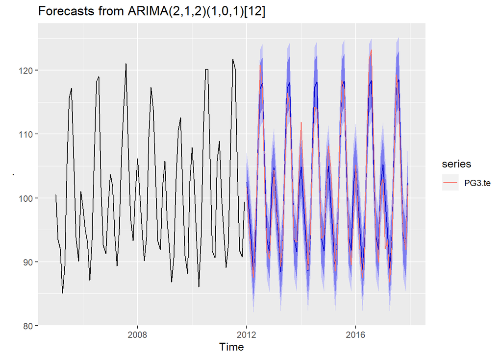

```r
autoplot(forecast_test_q7)+
autolayer(PG3.te)
```

- MAPE and MASE are almost similar. Hence, the model seems to have lower bias

####8. Forecasting future monthly US electricity generation:

- Now define the training and testing data set as:

```r
PG.tr <- window(PG, start=c(2005,1), end=c(2017,12))
PG.te <- window(PG, start=c(2018,1))
```

###### Use the **Arima(…)** function to fit the best model you have found thus far on PG.tr, run the model diagnostics to test the model validity and use it to extrapolate (forecast) the monthly generation of electricity in the US through the end of 2022 (i.e., forecast 60 months ahead).

```r
arima_q8 <-  PG.tr %>% Arima(order= c(3,1,3), seasonal= c(1,0,1))
print("Residual: ")
```

```
## [1] "Residual: "
```

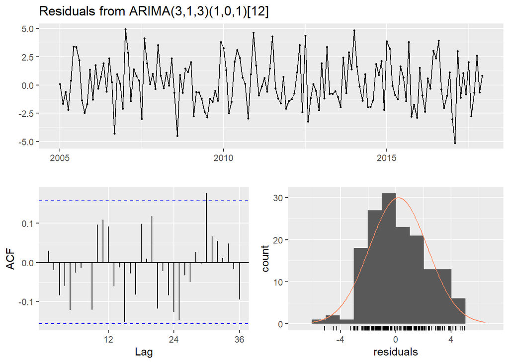

```
##
##  Ljung-Box test
##
## data:  Residuals from ARIMA(3,1,3)(1,0,1)[12]
## Q* = 29.389, df = 16, p-value = 0.02144
##
## Model df: 8.   Total lags used: 24
##
##
##  Ljung-Box test
##
## data:  Residuals from ARIMA(3,1,3)(1,0,1)[12]
## Q* = 29.389, df = 16, p-value = 0.02144
```

```r
print(checkresiduals(arima_q8))
```

- Overlay the available data for 2018 over the forecast. Comment on the model fit and validity.

```r
q8_ser <- PG.tr  %>% diff(2) %>% diff(lag = 12)
adf.test(q8_ser, alternative = 'stationary', k =12)
```

```
##
##  Augmented Dickey-Fuller Test
##
## data:  q8_ser
## Dickey-Fuller = -4.0218, Lag order = 12, p-value = 0.01022
## alternative hypothesis: stationary
```

Forecasting for next 60 months :

```r
forecast_q8 <- forecast(arima_q8,h=60)
print("60 months forecast : ")
```

```
## [1] "60 months forecast : "
```

```r
print(forecast_q8)
```

```
##          Point Forecast     Lo 80     Hi 80     Lo 95     Hi 95
## Jan 2018      105.83922 103.00709 108.67135 101.50786 110.17058
## Feb 2018       99.50505  96.08891 102.92119  94.28052 104.72958
## Mar 2018       94.18554  90.64233  97.72874  88.76667  99.60441
## Apr 2018       88.38727  84.79864  91.97591  82.89893  93.87561
## May 2018       93.85821  90.23197  97.48445  88.31235  99.40407
## Jun 2018      107.34593 103.71876 110.97311 101.79864 112.89322
## Jul 2018      118.08436 114.45181 121.71691 112.52885 123.63987
## Aug 2018      117.65655 114.01920 121.29391 112.09370 123.21941
## Sep 2018      104.81850 101.18102 108.45598  99.25546 110.38154
## Oct 2018       93.71160  90.07016  97.35304  88.14250  99.28070
## Nov 2018       91.37879  87.73690  95.02068  85.80900  96.94858
## Dec 2018      101.07971  97.43803 104.72139  95.51024 106.64917
## Jan 2019      105.70759 102.04596 109.36922 100.10761 111.30757
## Feb 2019       98.80783  95.14384 102.47182  93.20424 104.41142
## Mar 2019       94.26381  90.59902  97.92860  88.65899  99.86862
## Apr 2019       88.46699  84.79697  92.13700  82.85418  94.07979
## May 2019       93.47401  89.80464  97.14338  87.86219  99.08583
## Jun 2019      107.70234 104.03215 111.37253 102.08927 113.31542
## Jul 2019      118.01965 114.34766 121.69164 112.40383 123.63548
## Aug 2019      117.48189 113.81028 121.15350 111.86665 123.09713
## Sep 2019      105.20905 101.53555 108.88254  99.59092 110.82717
## Oct 2019       93.50693  89.83295  97.18092  87.88806  99.12581
## Nov 2019       91.41423  87.74024  95.08823  85.79534  97.03312
## Dec 2019      101.37428  97.69869 105.04988  95.75294 106.99563
## Jan 2020      105.44929 101.76689 109.13168  99.81754 111.08103
## Feb 2020       99.01075  95.32405 102.69744  93.37244 104.64906
## Mar 2020       94.40079  90.70897  98.09260  88.75465 100.04693
## Apr 2020       88.25789  84.56636  91.94942  82.61218  93.90360
## May 2020       93.76796  90.07513  97.46080  88.12026  99.41567
## Jun 2020      107.67970 103.98575 111.37365 102.03029 113.32912
## Jul 2020      117.92445 114.23095 121.61796 112.27573 123.57318
## Aug 2020      117.77317 114.07814 121.46819 112.12211 123.42422
## Sep 2020      105.07727 101.38198 108.77257  99.42581 110.72874
## Oct 2020       93.55374  89.85846  97.24901  87.90230  99.20517
## Nov 2020       91.63374  87.93667  95.33081  85.97956  97.28792
## Dec 2020      101.20709  97.51029 104.90389  95.55332 106.86086
## Jan 2021      105.61033 101.90377 109.31689  99.94164 111.27902
## Feb 2021       99.11615  95.40082 102.83147  93.43405 104.79825
## Mar 2021       94.27009  90.55432  97.98587  88.58731  99.95288
## Apr 2021       88.48156  84.76391  92.19922  82.79590  94.16723
## May 2021       93.76310  90.04394  97.48225  88.07514  99.45105
## Jun 2021      107.63152 103.91289 111.35016 101.94436 113.31869
## Jul 2021      118.14213 114.42200 121.86227 112.45268 123.83158
## Aug 2021      117.69059 113.97026 121.41092 112.00083 123.38034
## Sep 2021      105.12757 101.40736 108.84778  99.43800 110.81714
## Oct 2021       93.71961  89.99767  97.44156  88.02738  99.41185
## Nov 2021       91.53107  87.80890  95.25325  85.83849  97.22365
## Dec 2021      101.33795  97.61563 105.06026  95.64515 107.03074
## Jan 2022      105.69447 101.95800 109.43093  99.98004 111.40889
## Feb 2022       99.03983  95.29938 102.78029  93.31930 104.76036
## Mar 2022       94.44260  90.69944  98.18577  88.71793 100.16728
## Apr 2022       88.49004  84.74487  92.23521  82.76230  94.21778
## May 2022       93.74754  90.00246  97.49262  88.01994  99.47515
## Jun 2022      107.79874 104.05269 111.54479 102.06965 113.52783
## Jul 2022      118.09590 114.34938 121.84243 112.36608 123.82572
## Aug 2022      117.74162 113.99527 121.48797 112.01207 123.47117
## Sep 2022      105.25543 101.50801 109.00286  99.52424 110.98663
## Oct 2022       93.66154  89.91372  97.40936  87.92974  99.39333
## Nov 2022       91.64046  87.89207  95.38885  85.90779  97.37313
## Dec 2022      101.40913  97.65982 105.15844  95.67506 107.14320
```

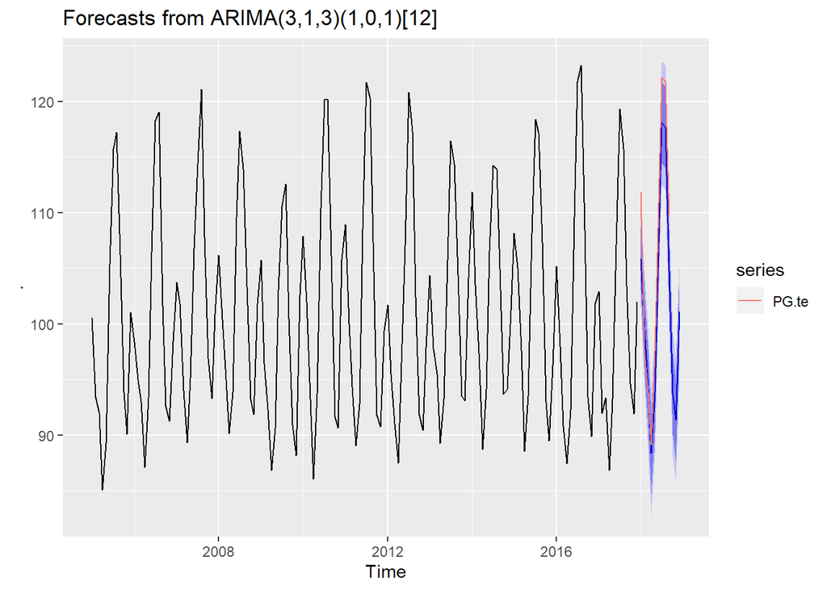

```r
forecast_q8 <- forecast(arima_q8,h=12)
autoplot(forecast_q8)+
autolayer(PG.te)
```

```r
print("Model Parameters:  ")
```

```
## [1] "Model Parameters:  "
```

```r
print(accuracy(forecast_q8, PG.te))
```

```
##                     ME     RMSE      MAE       MPE     MAPE      MASE
## Training set 0.1953387 2.100003 1.725732 0.1433245 1.686317 0.6376404
## Test set     2.7295855 3.727032 3.290449 2.4215452 3.000743 1.2157870
##                    ACF1 Theil's U
## Training set 0.03004445        NA
## Test set     0.16526536 0.3336587
```